# Lesson 6: Modeling nonlinearity

Last updated in April 2021

## Goals for today

- Learn how to model model nonlinearity using using:
  - categorization
  - Simple polynomials
  - Linear and natural splines

## Nonlinear relationships

- Nonlinear relationships are common in practice

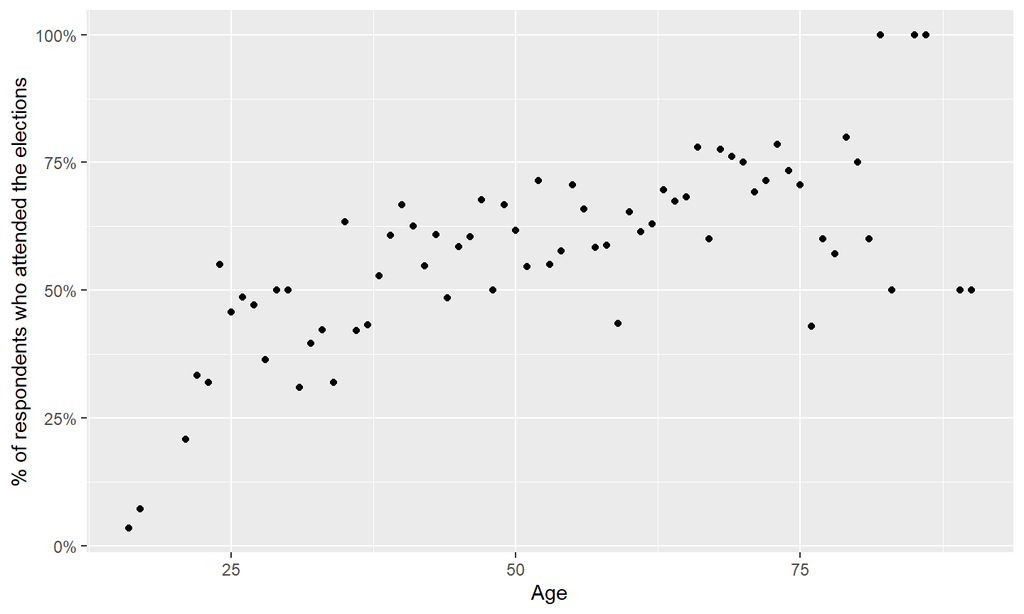

Age vs voter turnout in parlaiment election 2017, ESS

## Nonlinear relationships

- Modeling the relationship between voter turnout and age as linear is not sufficient

```r
mod1 = lm(vote ~ agea, data = vote)
```

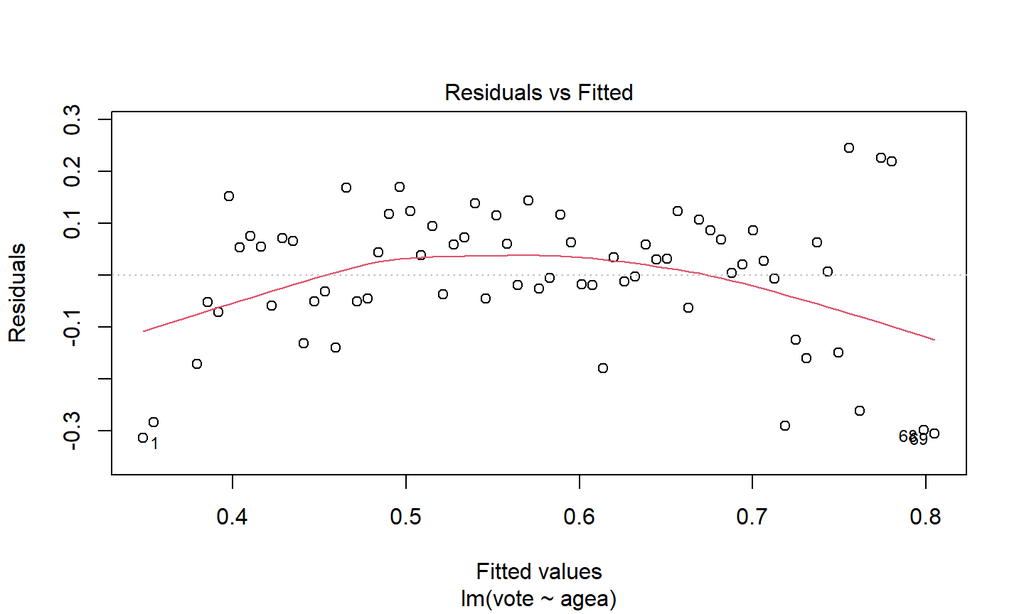

## Nonlinear models

- How can we change our model to capture the nonlinear relationship?
- Three popular options:
  - Categorizations
  - Simple polynomials
  - Splines

## Categorization

## Categorization

- Most basic way of dealing with nonlinearity
- We can transform numeric predictors into discrete categories and model them as ordinal
- There are many different ways a numerical variable can be cut into categories:
  - based on quantiles
  - to produce equaly wide intervals
  - to produce prespecified number of categories
  - based on theory

## Categorization - categories of equal range

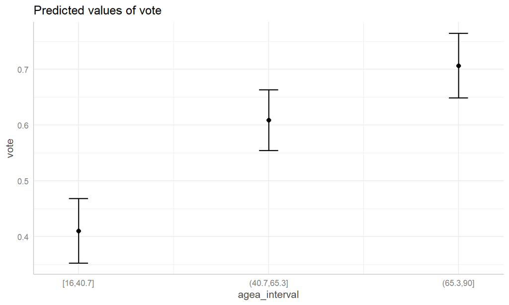

## Categorization - same number of observations

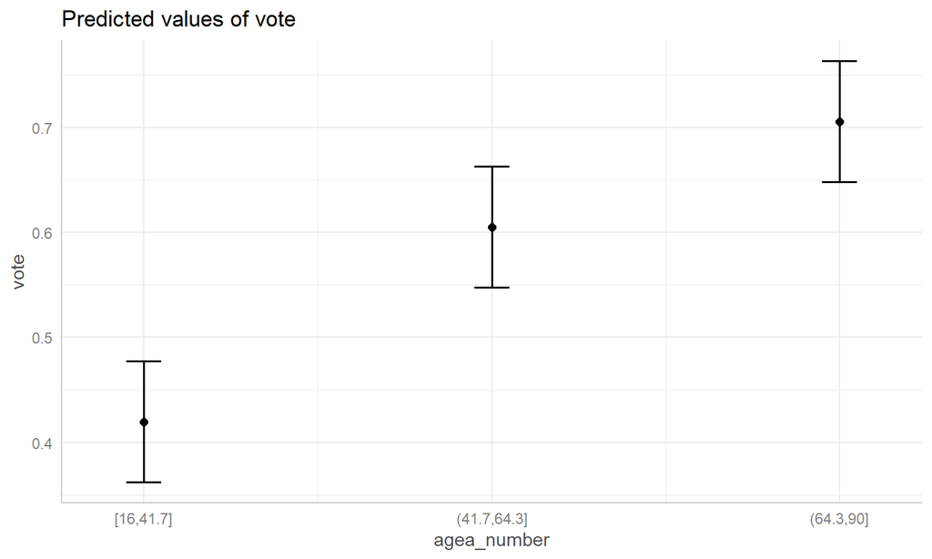

## Categorization - groups with specified width

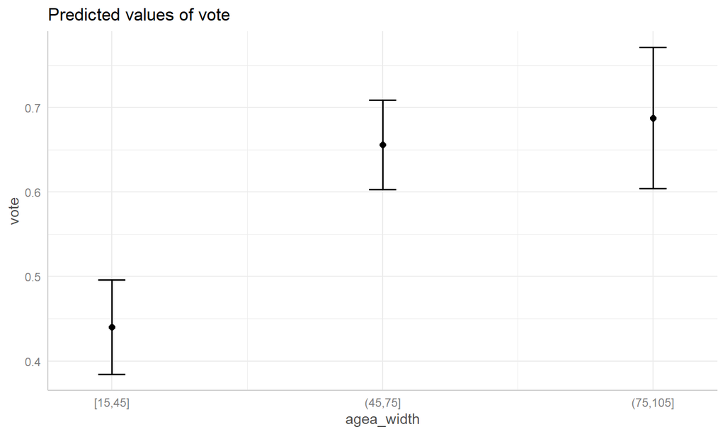

## Categorization - based on theory

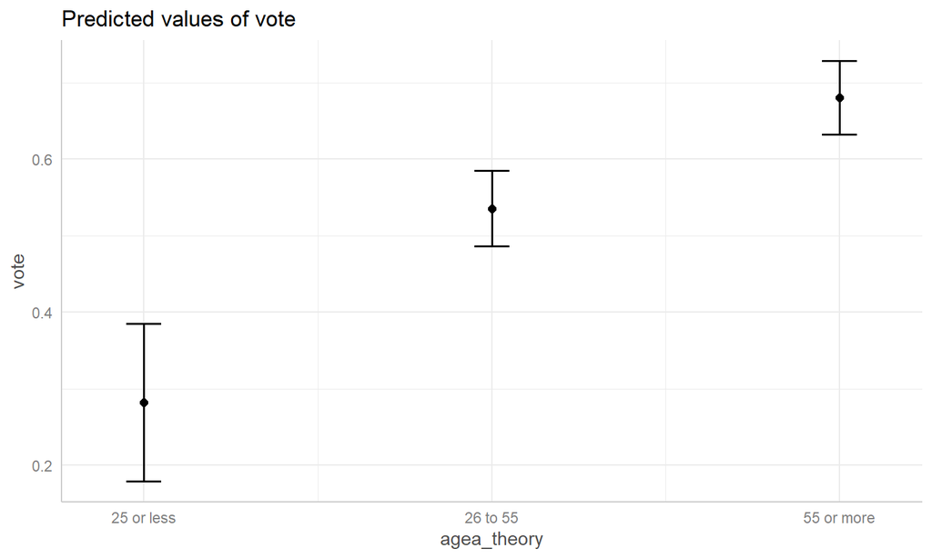

## R Intermezzo!

## Categorization - pros and cons

- The main advantage of categorizations is that the output is easily interpretable
- However, there are many technical drawbacks (Harrell, 2001):
  - Estimated values will have reduced precision, and associated tests will have reduced power
  - Categorization assumes that the relationship between the predictor and the response is flat within intervals
  - Categorization assumes that there is a discontinuity in response as interval boundaries are crossed.
  - Cutpoints are arbitrary and manipulatable; cutpoints can be found that can result in both positive and negative associations

## Categorization - often shown like this…

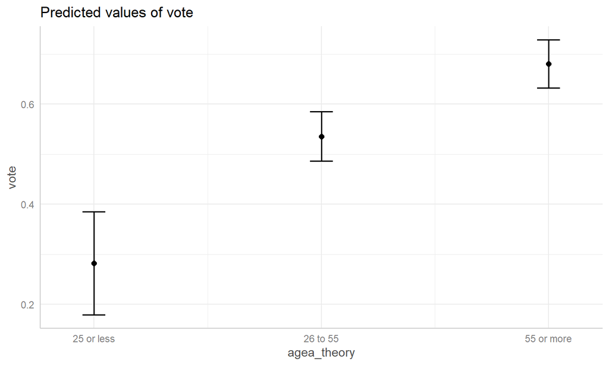

## Categorization - … but actually this

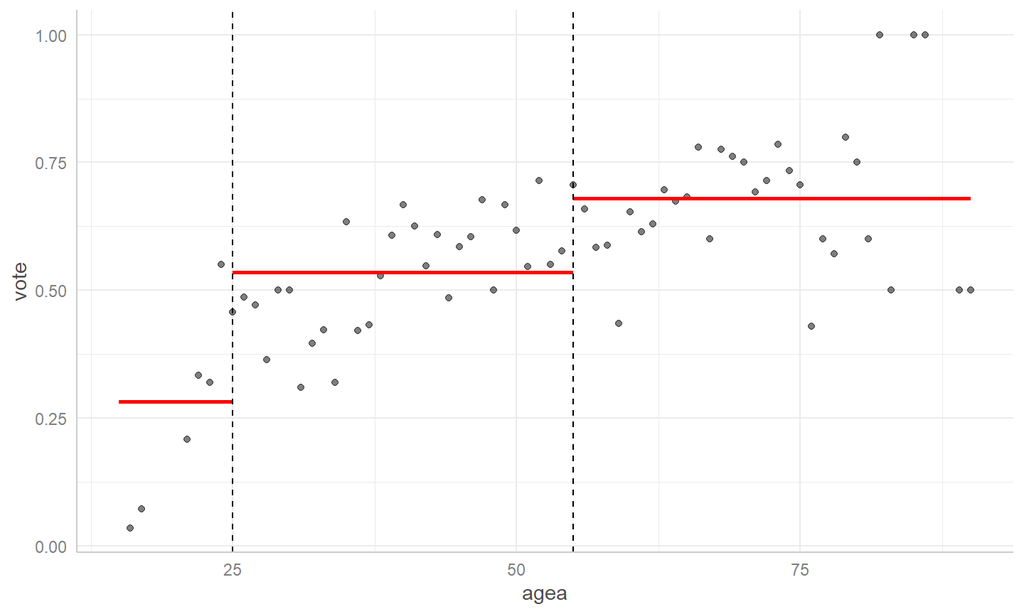

## Simple polynomials

## Polynomials

- Some of the problems of categorization can be solved by using simple polynomials (e.g. quadratic effect)

\[ vote = \beta_0 + \beta_1*age + \beta_2*age^2 \]

- We are essentialy trading the assumption that the relationship is linear for the assumption is in the form of a polynomial (e.g. parabola)

## Polynomials

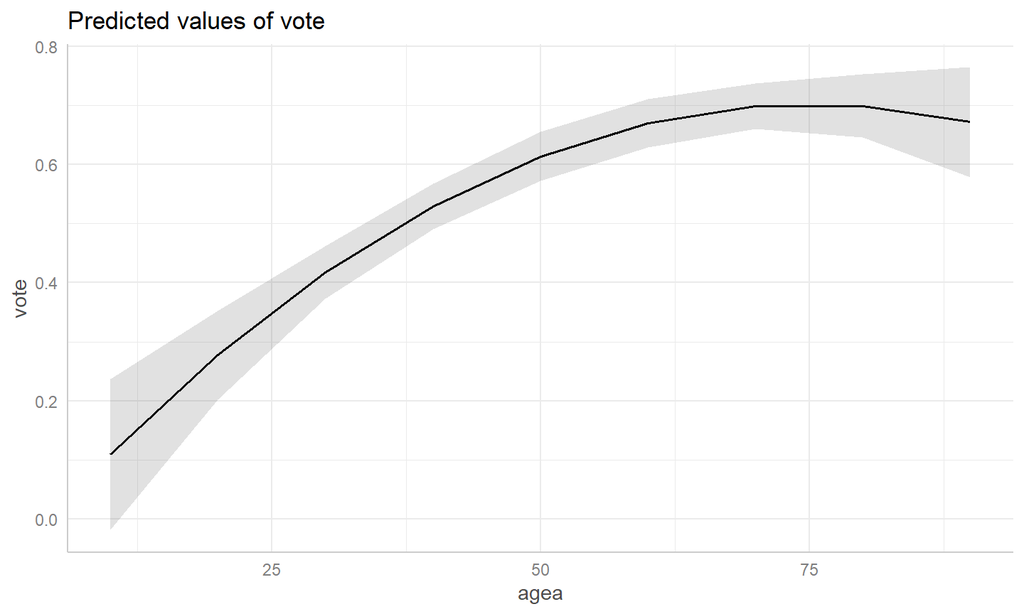

## Polynomials - raw and orthogonal types

- There are two types of polynomials: raw and orthogonal ones
  - Raw polynomial is simply a variable taken to the power of *k* (e.g. *age<sup>2</sup>*)
  - Orthogonal polynomials are computed so that the polynomials are uncorrelated with the lower forms (e.g. *age* will be uncorrelated with *age<sup>2</sup>*)
- The advantage of raw polynomials is that regression coefficients have the classic interpretation
- The advantage of orthogonal polynomials is that it’s easier to compute how much variance each of the forms predicts
- If you only want to control for a variable or are interpreting the model visualy, the choice doesn’t matter

## R Intermezzo!

## Polynomials - Pros and cons

- Simple polynomials alleviates some of the problems of categorization (arbitrary cutpoints, assumptions of flat intervals)
- However, two problems:
  - Polynomials can only capture polynomial relationships
  - Polynomials are extremely unstable at the ends

## Polynomials - Pros and cons

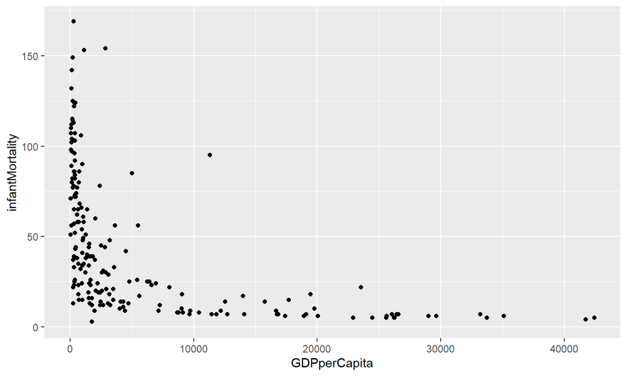

## Polynomials - Pros and cons

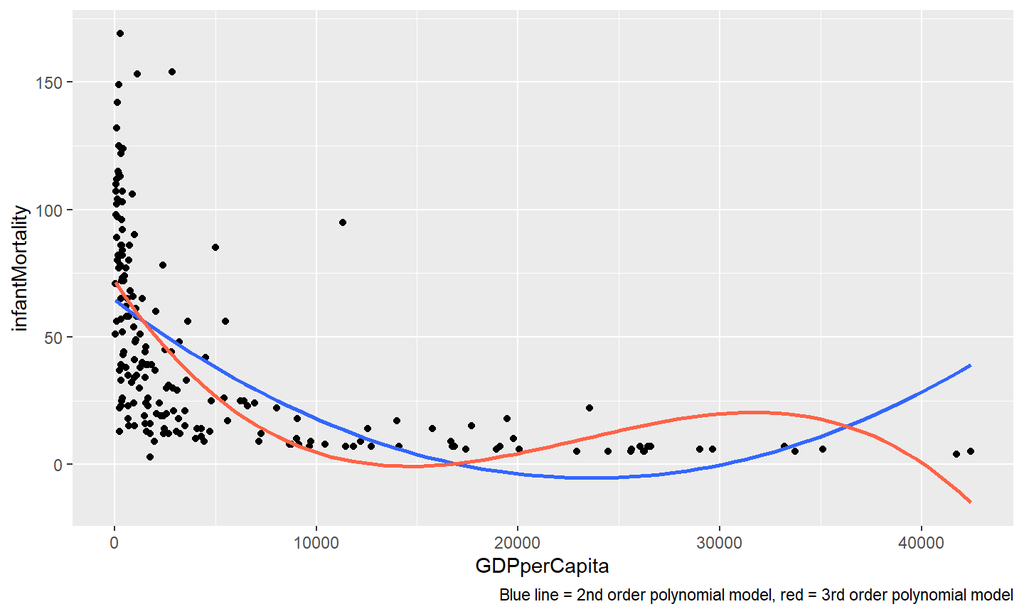

## Splines

## Splines

- Also known as piecewise regression
- Basic idea is simple - Instead of trying to fit a single line/curve through the entire data, cut it into smaller bins

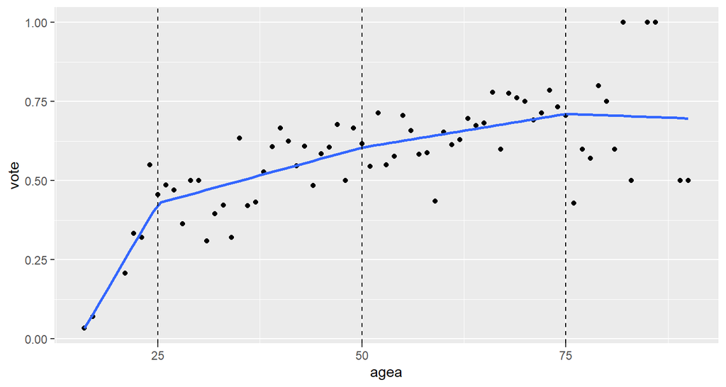

## Splines

- The values dividing individual bins are called knots
- General form of the model from previous slide:

\[ vote = \beta_0 + \beta_1*age_{<25} + \beta_2*age_{25-50} + \beta_3*age_{50-75} + \beta_3*age_{>75} \]

- We will learn about two types of splines: linear splines and natural splines (although many other types exists)

## Linear splines

- Linear splines divide the data into bins and then fit a (continuous) line through each of them

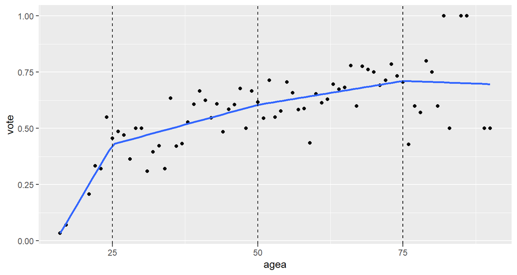

## Linear splines

- We can think of linear splines as a more flexible version of categorization
  - Still suffers with the problems of arbitrary cutpoins, same as categorization
  - BUT we no longer have the unrealistic assumptions that all observations inside a bin have the same value of the dependent variable
- Still, there is the problem of the the arbitrary knots positions and the sudden change in slope
- Can we do better?

## Natural splines

- also known as restricted cubic splines
- Instead of fitting lines, we fit polynomial (cubic) terms for the inner bins and lines for the outer ones

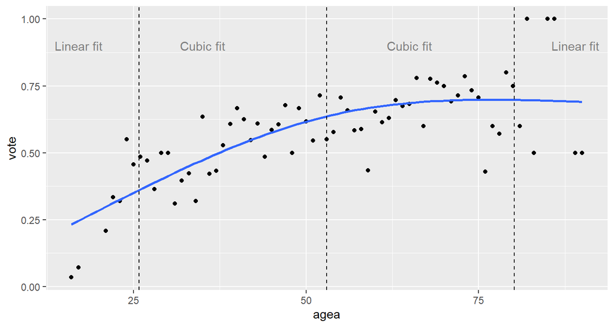

## Natural splines

- Natural splines solve both the problems of categorization/linear splines (sudden changes in slope, arbitrary cutpoints) and simple polynomials (only capturing polynomial relationships, unstable at the ends)
- Natural splines are one of the most flexible ways for modeling nonlinearity in the context of linear models

## R Intermezzo!

## Splines - Choosing cutpoints

- How to choose the number and position of cutpoints?
- Linear splines
  - Very sensitive to cutpoins position (same as categorization) -> best choose based on theory
- Natural splines
  - As long as the cutpoints are evenly spaced, their position matters less, what’s important is their number

## Splines - choosing cutpoins

- Typical position, based on Harrell (2001, p. 27):

[output not shown]

## Splines - choosing cutpoins

- But, as long as evenly spaced and symmetrical, the position of knots doesn’t matter for natural splines
- It is unlikely you will need more than 3-4 knots for most data
- Every knot is an additional parameter in the model -> you can use adjusted R<sup>2</sup> to test how many knots you need

## Nonlinearity - what to use?

## Nonlinearity - what to use?

- Use categorization when presenting your analysis to lay audience.
- Use linear splines if you present to professionals, but still want interpretable regression coefficients.
- Use natural/restricted cubic splines if you are analyzing potentially complex relationships and are comfortable with using marginal effect plots.
- Avoid simple polynomials altogether.

## Nonlinearity - what to use?

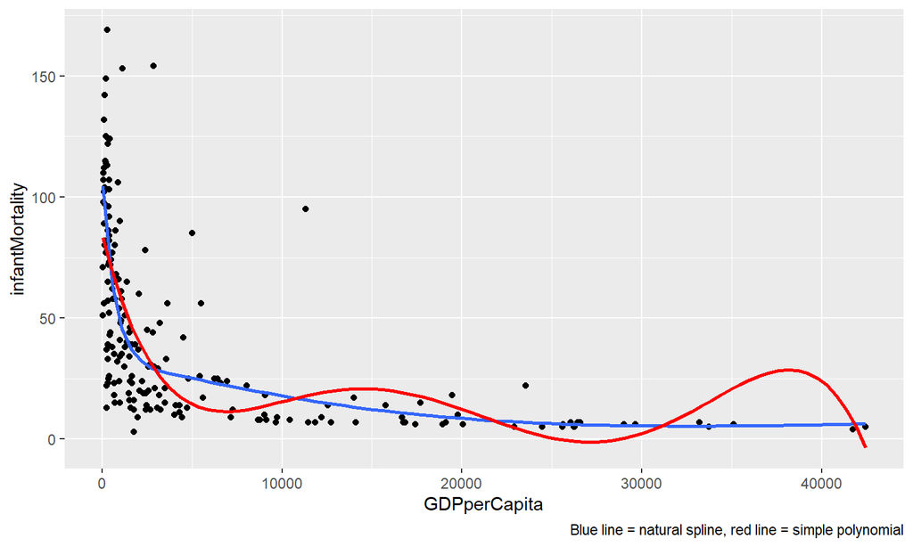

## References

Harrell, F. (2001). *Regression Modeling Strategies: With Applications to Linear Models, Logistic Regression, and Survival Analysis*. Springer-Verlag. https://doi.org/10.1007/978-1-4757-3462-1